# Monocle3: trajectory analysis

Monocle3を用いた疑似時系列解析 (pseudo-time analysis) を行います。Rstudioに "Monocle3"というプロジェクトを新規作成し、その中で作業します。 用いるデータは [Packer & Zhu et al.](https://science.sciencemag.org/content/365/6459/eaax1971) による線虫のembryoからの細胞分化データです。

Monocle3は軌道解析以外にもクラスタリングなどの機能も備えています。それらの操作については [Getting started with Monocle 3](https://cole-trapnell-lab.github.io/monocle3/docs/starting/) を参照してください。

## Monocle3のインストール

Monocle2はBioconductorを用いてインストール可能ですが、Monocle3は今のところGithub上で公開されている開発版であり、インストール方法がやや複雑です。以下のコマンドでインストールしてください。Rのバージョンは3.6以上が必要です。

```r
install.packages("BiocManager")
BiocManager::install(c('BiocGenerics', 'DelayedArray', 'DelayedMatrixStats',
                    'limma', 'S4Vectors', 'SingleCellExperiment',
                    'SummarizedExperiment', 'batchelor'))
install.packages("devtools")
devtools::install_github('cole-trapnell-lab/leidenbase')
devtools::install_github('cole-trapnell-lab/monocle3', ref="develop")
```

```r
# 元URL: https://cole-trapnell-lab.github.io/monocle3/docs/trajectories/
```

## データ読み込み、前処理、正規化

```r
library(monocle3)
library(dplyr)
```

```r
# データ読み込み
expression_matrix <- readRDS(url("http://staff.washington.edu/hpliner/data/packer_embryo_expression.rds"))
cell_metadata <- readRDS(url("http://staff.washington.edu/hpliner/data/packer_embryo_colData.rds"))
gene_annotation <- readRDS(url("http://staff.washington.edu/hpliner/data/packer_embryo_rowData.rds"))

cds <- new_cell_data_set(expression_matrix,
                      cell_metadata = cell_metadata,
                      gene_metadata = gene_annotation)
```

```r
### 参考: 10Xディレクトリを指定する場合
# cds <- load_cellranger_data("./10x_data")
```

### 前処理、バッチエフェクトの処理

```r
cds <- preprocess_cds(cds, num_dim = 50)
cds <- align_cds(cds, alignment_group = "batch",
                 residual_model_formula_str = "~ bg.300.loading + bg.400.loading + bg.500.1.loading + bg.500.2.loading + bg.r17.loading + bg.b01.loading + bg.b02.loading")

cds@colData
```

```
Aligning cells from different batches using Batchelor.
Please remember to cite:
	 Haghverdi L, Lun ATL, Morgan MD, Marioni JC (2018). 'Batch effects in single-cell RNA-sequencing data are corrected by matching mutual nearest neighbors.' Nat. Biotechnol., 36(5), 421-427. doi: 10.1038/nbt.4091
```

```
DataFrame with 6188 rows and 19 columns
                                             cell     n.umi  time.point
                                      <character> <numeric>    <factor>
AAACCTGCAAGACGTG-300.1.1 AAACCTGCAAGACGTG-300.1.1      1003 300_minutes
AAACCTGGTGTGAATA-300.1.1 AAACCTGGTGTGAATA-300.1.1      1458 300_minutes
AAACCTGTCGGCCGAT-300.1.1 AAACCTGTCGGCCGAT-300.1.1      1633 300_minutes
AAAGATGGTTCGTTGA-300.1.1 AAAGATGGTTCGTTGA-300.1.1      1716 300_minutes
AACCATGAGAAACCTA-300.1.1 AACCATGAGAAACCTA-300.1.1      1799 300_minutes
...                                           ...       ...         ...
TGATTTCCAGTCTTCC-b02         TGATTTCCAGTCTTCC-b02       589       mixed
TGCGCAGCAGGATTGG-b02         TGCGCAGCAGGATTGG-b02       658       mixed
TGCGCAGTCCCTGACT-b02         TGCGCAGTCCCTGACT-b02       536       mixed
TGCGGGTAGTACTTGC-b02         TGCGGGTAGTACTTGC-b02       549       mixed
TTTGTCAAGTACACCT-b02         TTTGTCAAGTACACCT-b02       542       mixed
                                         batch Size_Factor raw.embryo.time
                                      <factor>   <numeric>       <integer>
AAACCTGCAAGACGTG-300.1.1 Waterston_300_minutes    0.779569             350
AAACCTGGTGTGAATA-300.1.1 Waterston_300_minutes    1.133212             190
AAACCTGTCGGCCGAT-300.1.1 Waterston_300_minutes    1.269229             260
AAAGATGGTTCGTTGA-300.1.1 Waterston_300_minutes    1.333740             220
AACCATGAGAAACCTA-300.1.1 Waterston_300_minutes    1.398250             340
...                                        ...         ...             ...
TGATTTCCAGTCTTCC-b02                Murray_b02    0.457793             700
TGCGCAGCAGGATTGG-b02                Murray_b02    0.511422             750
TGCGCAGTCCCTGACT-b02                Murray_b02    0.416599             700
TGCGGGTAGTACTTGC-b02                Murray_b02    0.426703             380
TTTGTCAAGTACACCT-b02                Murray_b02    0.421263             620
                         embryo.time embryo.time.bin raw.embryo.time.bin
                           <numeric>        <factor>            <factor>
AAACCTGCAAGACGTG-300.1.1         350         330-390             330-390
AAACCTGGTGTGAATA-300.1.1         190         170-210             170-210
AAACCTGTCGGCCGAT-300.1.1         245         210-270             210-270
AAAGATGGTTCGTTGA-300.1.1         225         210-270             210-270
AACCATGAGAAACCTA-300.1.1         325         270-330             330-390
...                              ...             ...                 ...
TGATTTCCAGTCTTCC-b02             640         580-650             > 650
TGCGCAGCAGGATTGG-b02             700         > 650               > 650
TGCGCAGTCCCTGACT-b02             700         > 650               > 650
TGCGGGTAGTACTTGC-b02             450         450-510             330-390
TTTGTCAAGTACACCT-b02             700         > 650               580-650
```

[output cut: 37 more lines]

```
TGCGGGTAGTACTTGC-b02             -1.68906         -0.67517       -1.68877
TTTGTCAAGTACACCT-b02             -5.47903         -4.00471       -5.85036
                         bg.b01.loading bg.b02.loading
                              <numeric>      <numeric>
AAACCTGCAAGACGTG-300.1.1      -2.284804      -2.130261
AAACCTGGTGTGAATA-300.1.1       1.640686       0.153481
AAACCTGTCGGCCGAT-300.1.1      -0.137057      -0.518981
AAAGATGGTTCGTTGA-300.1.1      -0.961214      -2.266003
AACCATGAGAAACCTA-300.1.1      -2.935370      -2.613732
...                                 ...            ...
TGATTTCCAGTCTTCC-b02          -1.462521       1.731990
TGCGCAGCAGGATTGG-b02          -4.966875      -1.006235
TGCGCAGTCCCTGACT-b02          -2.726794       0.990014
TGCGGGTAGTACTTGC-b02          -0.113764       2.838543
TTTGTCAAGTACACCT-b02          -3.990287       0.329801
```

## 次元削減

Monocle3はデフォルトでUMAPを次元削減に使います。

```r
cds <- reduce_dimension(cds)
```

```
No preprocess_method specified, and aligned coordinates have been computed previously. Using preprocess_method = 'Aligned'
```

```
No trajectory to plot. Has learn_graph() been called yet?

Warning message:
“Removed 1 rows containing missing values (geom_text_repel).”
```

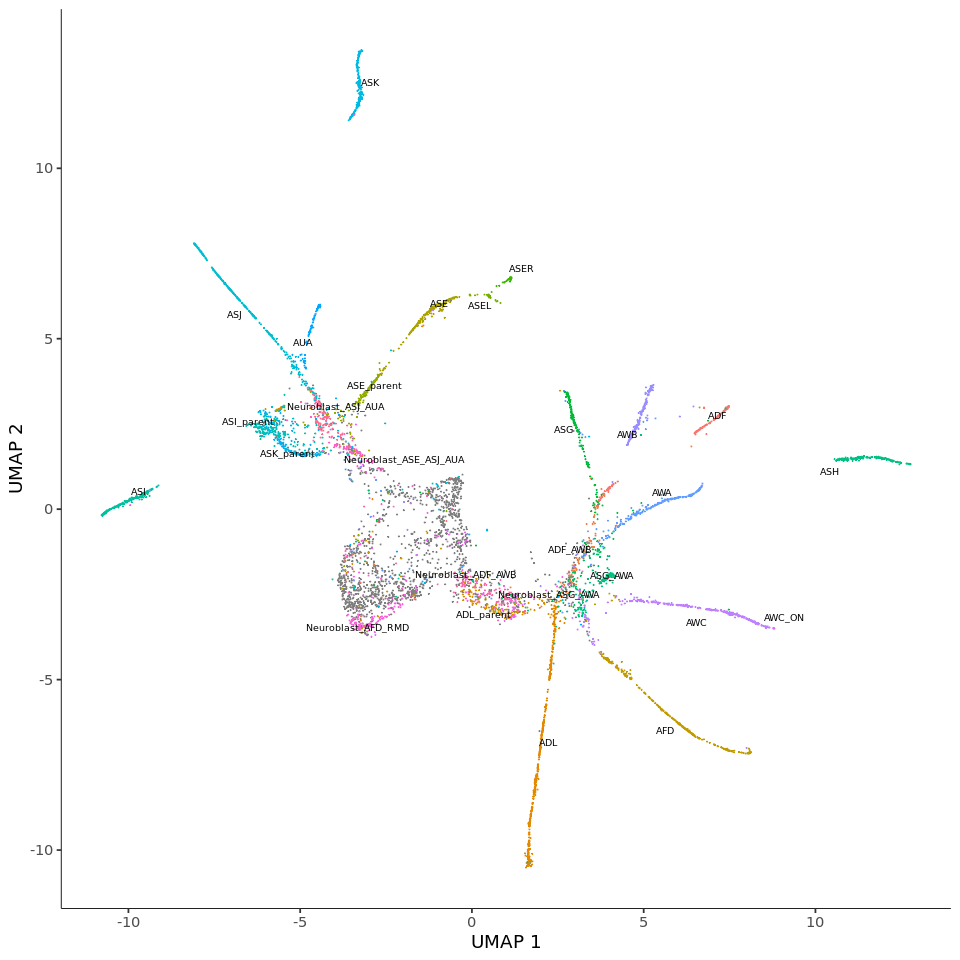

```r
# 可視化
options(repr.plot.width = 8, repr.plot.height = 8)
plot_cells(cds, label_groups_by_cluster=FALSE,  color_cells_by = "cell.type")
```

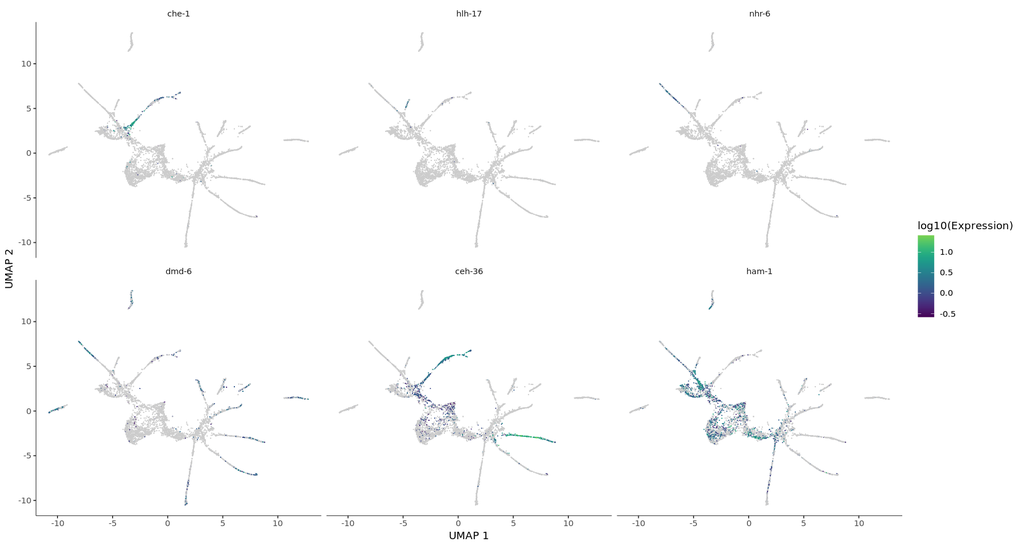

```r
# 指定した遺伝子の発現量を可視化
options(repr.plot.width = 15, repr.plot.height = 8)

ciliated_genes <- c("che-1", "hlh-17", "nhr-6", "dmd-6", "ceh-36", "ham-1")
plot_cells(cds, genes=ciliated_genes, label_cell_groups=FALSE, show_trajectory_graph=FALSE)
```

## クラスタリング

ひとつのサンプル内に複数の軌道が含まれる（複数の「祖先」細胞がある）可能性を考慮するため、クラスタリングによって得られたクラスタそれぞれで軌道解析を行います。

```
No trajectory to plot. Has learn_graph() been called yet?
```

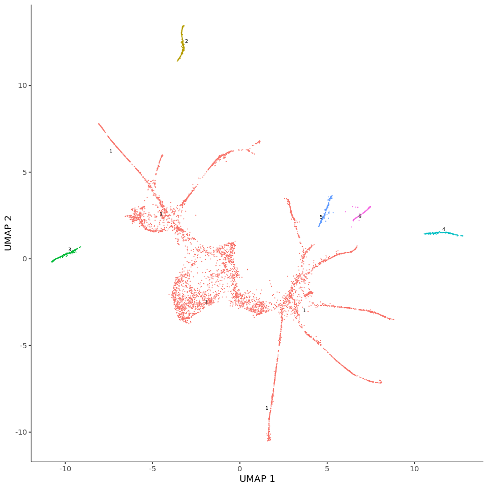

```r
options(repr.plot.width = 8, repr.plot.height = 8)

cds <- cluster_cells(cds)
plot_cells(cds, color_cells_by = "partition")
```

## 軌道推定

各クラスタについて軌道推定します。

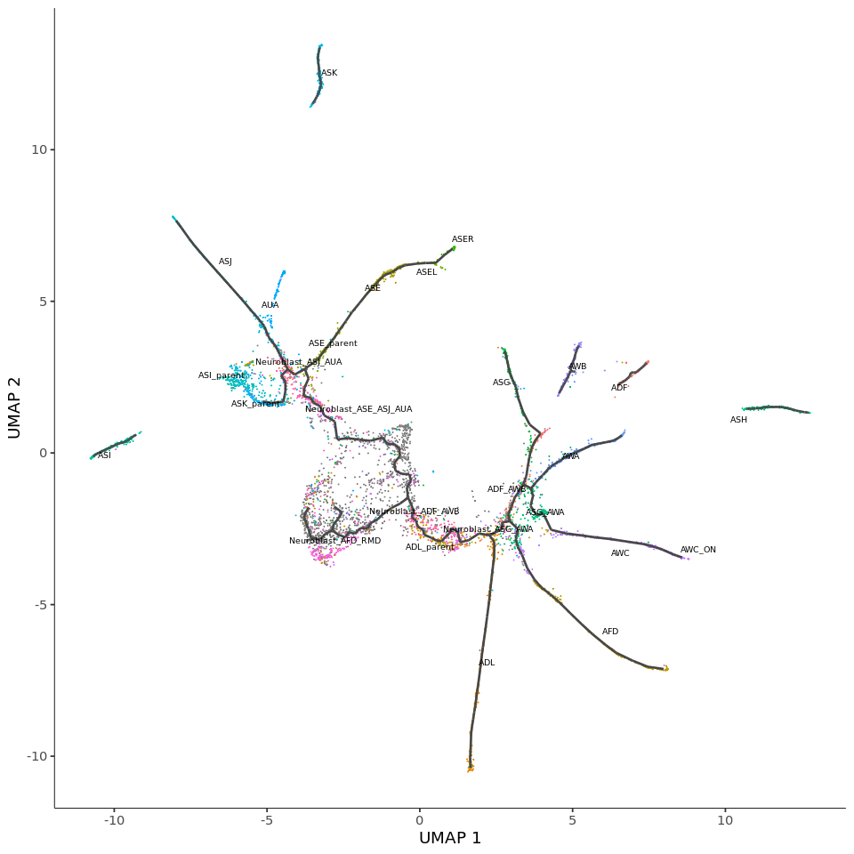

```r
cds <- learn_graph(cds)
plot_cells(cds,
        color_cells_by = "cell.type",
        label_groups_by_cluster=FALSE,
        label_leaves=FALSE,
        label_branch_points=FALSE)
```

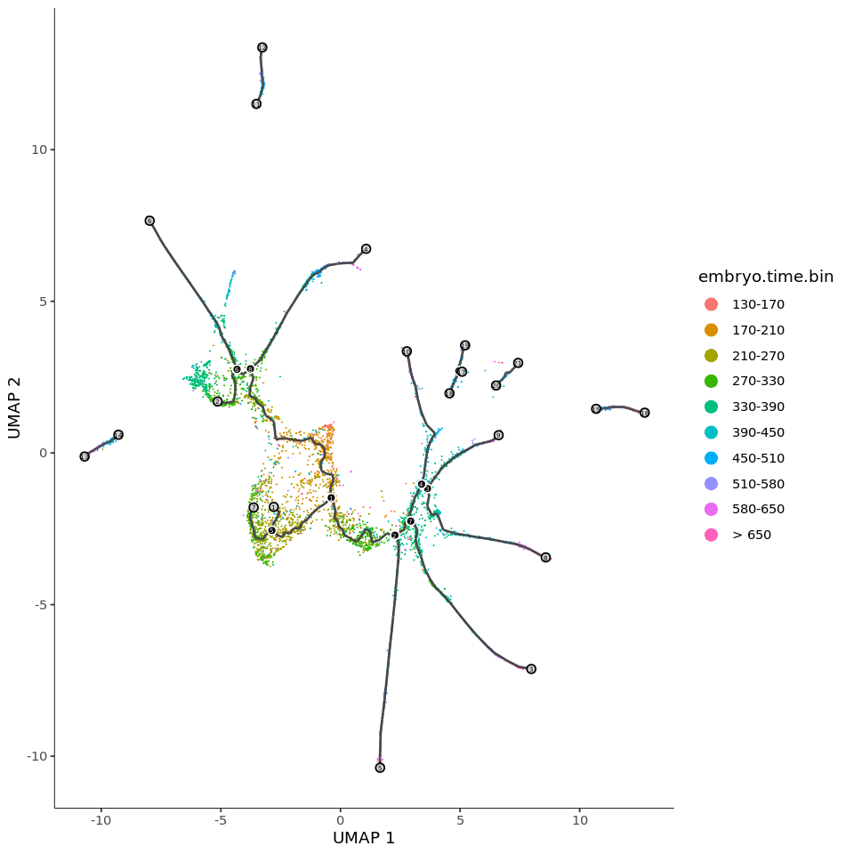

```r
# 細胞を軌道（疑似時間軸）に沿ってソート
plot_cells(cds, color_cells_by = "embryo.time.bin",
        label_cell_groups=FALSE,
        label_leaves=TRUE,
        label_branch_points=TRUE,
        graph_label_size=1.5)
```

全ての細胞が軌道に含まれるわけではないことに注意してください。灰色の丸は各軌道の終点（cell fate）を、黒色の丸は分岐点（branch point）を示します。

## rootをマニュアルで指定（GUI）

(注：この一連のコマンドはRのGUIを使うため、Jupyterでは表示できません。ここではコマンドのみ示しますが、どのようになるかは是非自分でチェックしてみてください。)

```r
# order_cellsコマンドでソート画面を起動し、rootをどこにするかを指定します。 複数のrootを指定することも可能です。
cds <- order_cells(cds)
```

```r
# 以下のコマンドで軌道の方向性が決定されます。

plot_cells(cds, color_cells_by = "pseudotime",
        label_cell_groups=FALSE,
        label_leaves=FALSE,
        label_branch_points=FALSE,
        graph_label_size=1.5)
```

軌道に含まれていない細胞（rootと接続されていない細胞）は灰色で表示されます。

## rootを自動推定

以下のコマンドを実行すると、rootを自動で推定します。 細胞を最近傍の軌道ノードに割り当て、early stageの細胞が最も多く割り当てられているノードをrootとして同定します。

```r
get_earliest_principal_node <- function(cds, time_bin="130-170"){
  cell_ids <- which(colData(cds)[, "embryo.time.bin"] == time_bin)

closest_vertex <- cds@principal_graph_aux[["UMAP"]]$pr_graph_cell_proj_closest_vertex
closest_vertex <- as.matrix(closest_vertex[colnames(cds), ])
root_pr_nodes <- igraph::V(principal_graph(cds)[["UMAP"]])$name[as.numeric(names(which.max(table(closest_vertex[cell_ids,]))))]

root_pr_nodes
}
cds <- order_cells(cds, root_pr_nodes=get_earliest_principal_node(cds))
```

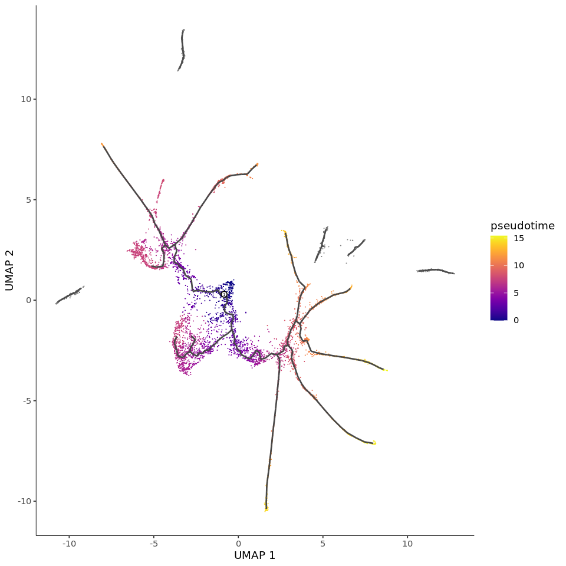

```r
#可視化

plot_cells(cds, color_cells_by = "pseudotime",
        label_cell_groups=FALSE,
        label_leaves=FALSE,
        label_branch_points=FALSE,
        graph_label_size=1.5)
```

```r
# 関数 choose_graph_segments を使うことで、特定のブランチのサブセットを抽出できる（GUI要）。
cds_sub <- choose_graph_segments(cds)
```

## 3次元空間での軌道解析

```r
cds_3d <- reduce_dimension(cds, max_components = 3)
cds_3d <- cluster_cells(cds_3d)
cds_3d <- learn_graph(cds_3d)
cds_3d <- order_cells(cds_3d, root_pr_nodes=get_earliest_principal_node(cds))

cds_3d_plot_obj <- plot_cells_3d(cds_3d, color_cells_by="partition")
```

```
No preprocess_method specified, and aligned coordinates have been computed previously. Using preprocess_method = 'Aligned'
```

## 軌道に沿って発現変化する遺伝子の同定

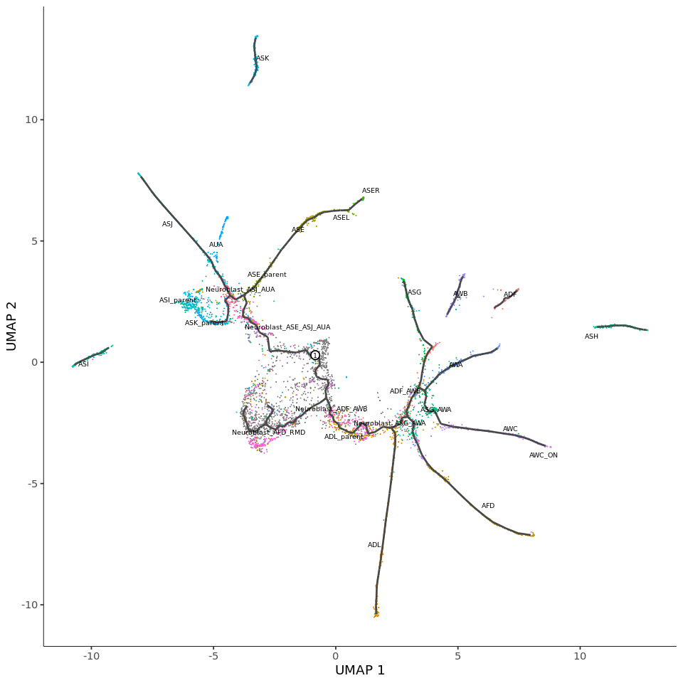

```r
# 元URL: https://cole-trapnell-lab.github.io/monocle3/docs/differential/

# 細胞種ごとに色分けして可視化
plot_cells(cds, color_cells_by = "cell.type",
        label_groups_by_cluster=FALSE,
        label_leaves=FALSE,
        label_branch_points=FALSE)
```

graph_test (発現変動解析のためのコマンド) に neighbor_graph="principal_graph" オプションを追加することで、軌道上で近い細胞ごとに分けて発現変動解析をするようになります。

```r
# 以下はかなり時間がかかります。
# cores=12 で12CPUを使う
ciliated_cds_pr_test_res <- graph_test(cds, neighbor_graph="principal_graph", cores=12)
pr_deg_ids <- row.names(subset(ciliated_cds_pr_test_res, q_value < 0.05))
```

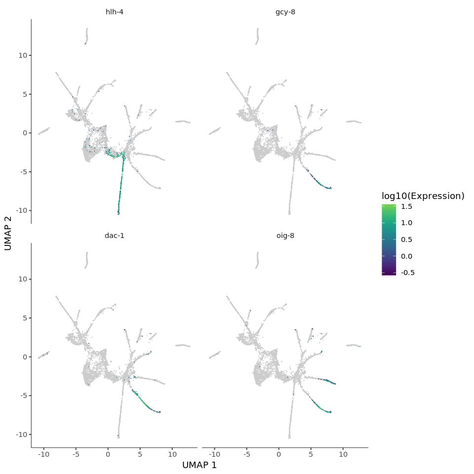

```r
# 得られた遺伝子の可視化

plot_cells(cds, genes=c("hlh-4", "gcy-8", "dac-1", "oig-8"),
        show_trajectory_graph=FALSE,
        label_cell_groups=FALSE,
        label_leaves=FALSE)
```

## 遺伝子モジュールの可視化

```r
# 軌道ごとのtrajectory-variable genesを遺伝子モジュールとして定義
## (注：公式Tutorialでは resolution=c(0,10^seq(-6,-1)) となっているのですが、
## 手元の環境ではそれだとinput parameter error(s): -> resolution_parameter <= 0　とエラーなるため、
## ここでは c(10^seq(-6,-1)) を指定しています)

gene_module_df <- find_gene_modules(cds[pr_deg_ids,], resolution=c(10^seq(-6,-1)))
```

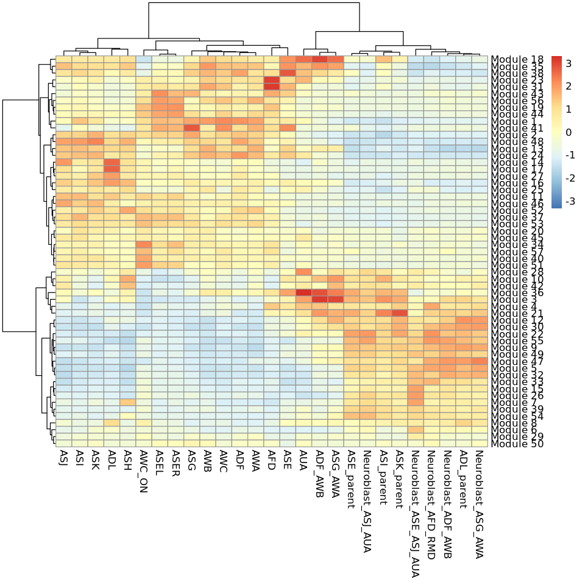

```r
#モジュール単位での発現量をヒートマップで可視化

cell_group_df <- tibble::tibble(cell=row.names(colData(cds)), cell_group=colData(cds)$cell.type)
agg_mat <- aggregate_gene_expression(cds, gene_module_df, cell_group_df)
row.names(agg_mat) <- stringr::str_c("Module ", row.names(agg_mat))
pheatmap::pheatmap(agg_mat, scale="column", clustering_method="ward.D2")
```

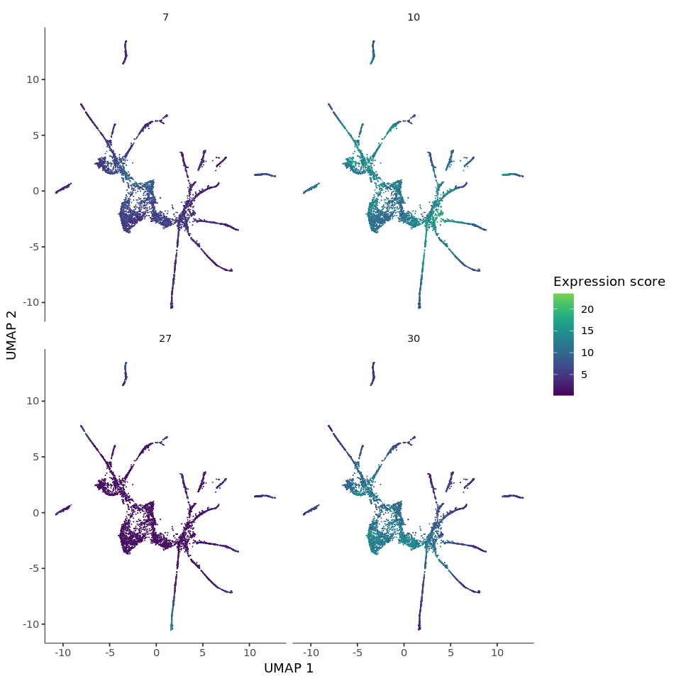

```r
#モジュール単位での発現量を2次元マップ上で可視化

plot_cells(cds,
        genes=gene_module_df %>% filter(module %in% c(27, 10, 7, 30)),
        label_cell_groups=FALSE,
        show_trajectory_graph=FALSE)
```

## その他の可視化

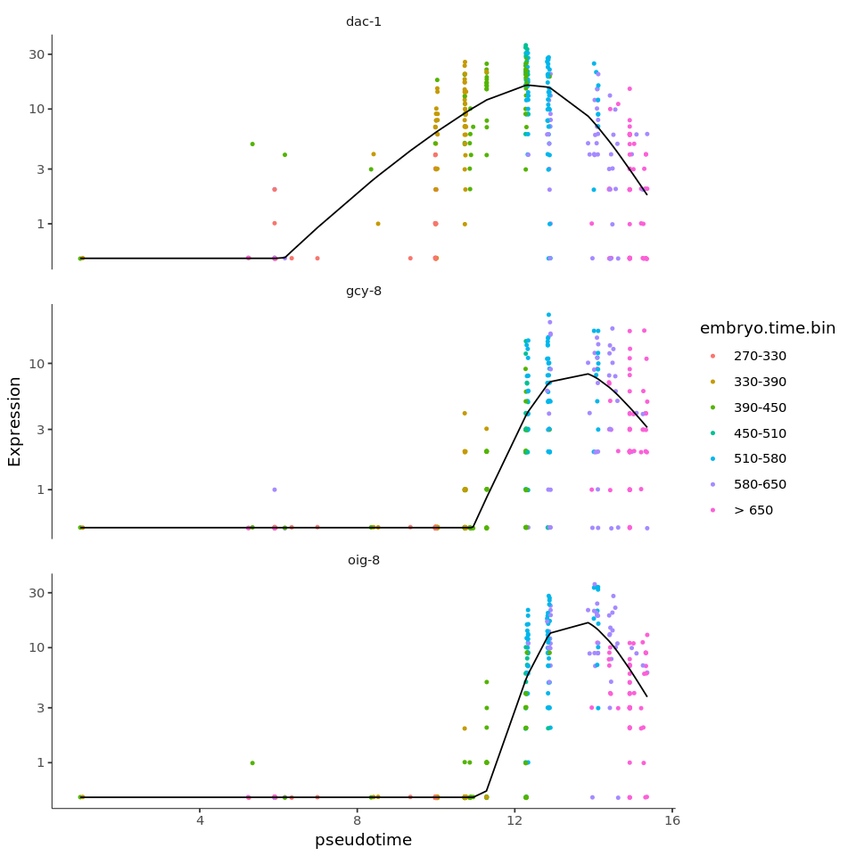

```r
# 指定した軌道上の発現ダイナミクスの可視化

AFD_genes <- c("gcy-8", "dac-1", "oig-8")
AFD_lineage_cds <- cds[rowData(cds)$gene_short_name %in% AFD_genes,
                    colData(cds)$cell.type %in% c("AFD")]
plot_genes_in_pseudotime(AFD_lineage_cds,
                      color_cells_by="embryo.time.bin",
                      min_expr=0.5)
```

```r
#特定のブランチ（部分細胞群）の抽出・可視化（GUI要）

# GUIを起動し、部分細胞群を矩形で指定
cds_subset <- choose_cells(cds)
# 選択したブランチに対して変動解析を実行
subset_pr_test_res <- graph_test(cds_subset, neighbor_graph="principal_graph", cores=4)
pr_deg_ids <- row.names(subset(subset_pr_test_res, q_value < 0.05))
# 遺伝子モジュールを抽出
gene_module_df <- find_gene_modules(cds_subset[pr_deg_ids,], resolution=0.001)
# 可視化
agg_mat <- aggregate_gene_expression(cds_subset, gene_module_df)
module_dendro <- hclust(dist(agg_mat))
gene_module_df$module <- factor(gene_module_df$module,
                         levels = row.names(agg_mat)[module_dendro$order])

plot_cells(cds_subset, genes=gene_module_df,
        label_cell_groups=FALSE,
        show_trajectory_graph=FALSE)
```